# Introduction to R

Isabelle Laforest-Lapointe, Amy Heim, Sophie Boutin, Jonathan Rondeau-Leclaire

This tutorial was created for a 3-day free R introduction workshop organized by the [Laforest-Lapointe Lab](https://www.laforestlab.com/) at Université de Sherbrooke on May 12th-14th.

# 1 Session 1 - Monday AM

R is an object-oriented programming language. Essentially, this means that data, values, inputs and outputs are saved as “objects” whose names are defined by the user. Objects can then be used to perform calculations, data manipulation, or visualisations.

**Objectives:**

1. Familiarise ourseves with RStudio
2. Learn the syntax of the R language
3. Learn to work with objects

## 1.1 RStudio Environment

RStudio is a program that allows you to write a series of command as a script, have R execute these commands, visualise the output and see the objects that you create.

**Top left: Script**

Document where you will write the command lines. To create a script: `File > New File > R Script`. Save regularly!

Execute commands, place your cursor in the command’s line and press: `Command + Enter` for Mac, `Control + Enter` for Windows.

**Bottom left: Console**

Where the output of the command line will appear. When you execute commands from the script, the command and its output (or error messages!) will appear there.

Use it to execute commands that you do not want to save in the script or to test your commands before adding them to the script. To execute a command from the console, simply press `enter` after writing it.

**Top right: Environment**

Place where all the objects you create (dataframes, values, vectors) are shown. Click on any object to visualise it.

**Bottom right: Files, Plots, Help**

This is a files and plots viewer as well as the help center.

## 1.2 Syntax

### 1.2.1 Basic R usage

The very simplest thing you can do is use R as a calculator and get the output from the console:

```r
# Everything written after a hashtag is a comment (cannot be executed)
2+4
```

```
## [1] 6
```

But we like to do more exciting things. Generally, we save values in objects and then execute operations on those objects.

Most R operations are written like this:

```
an_object <- a_value
```

This stores a value in an object named an_object. The value can be, for example, a single number, a character string, or a complex object like a matrix or a list. It can be user-written (“hardcoded”) like above, or be the output of a function, such as:

```
an_object <- a_function(values, some_parameters)
```

In this case, the function takes values as an input, applies operations to it, and spits out new values. Parameters are generally optional ways to control the behaviour of the function. Concrete examples will be presented in the next few sections.

```r
# Store the output in an object
res <- 2+4
res
```

```
## [1] 6
```

```r
# Multiply the result
2*res
```

```
## [1] 12
```

### 1.2.2 Useful symbols

R uses many characters that have a specific role. Some are essential to know, which we present in this section.

- `$` access an element of an object by its name (e.g. the column of a data frame)
- `[]` access an element of an object by its index (e.g. `vector[3]` accesses the 3rd element in than vector)
- `<-` assign an object (shortcut: `alt` + `-` on Windows, `option`+ `-` on mac)
- `=` assign an object; specify function parameters
- `""` and `''` are used to express strings (character values)
- `?` used to learn how a function work. `?sum` will open a help file where you can learn about how to use that function.

### 1.2.3 Comparison operators

To compare values to one another:

- `==` equal
- `!=` is not equal

The following can only be used for numeric values:

- `<` smaller than
- `>` greater than
- `<=` smaller or equal to
- `>=` greater or equal to

```r
5 > 6
```

```
## [1] FALSE
```

```r
5 <= 6
```

```
## [1] TRUE
```

`TRUE` and `FALSE` are boolean values with a specific meaning. They represent a type of information that can only be true or false.

```r
5 != 4+1
```

```
## [1] FALSE
```

### 1.2.4 Logical operators

- `&` and
- `|` or

They are used to test multiple conditions at once

```r
(5 == 5) & (6 == 6)
```

```
## [1] TRUE
```

```r
(5 == 4) & (6 == 6)
```

```
## [1] FALSE
```

```r
(5 == 4) | (6 == 6)
```

```
## [1] TRUE
```

## 1.3 Object classes

Objects and object components (e.g., data frame variables) always have a class. This class gives you a hint on how it will behave.

We can also see a composite class, `data.frame`. These are used for more complex objects, usually with two dimensions. Other composite classes include `matrix`, which are similar to data frames (the difference between these two is that data frames can contain elements of various classes). There are also `list` and `array`, which won’t be covered in this course.

`Character`  
`Numeric`  
`Integer`  
`Factor`  
`Logical`  
`Date`  
`Vector`  
`Data frame`  
`Matrix`

Let’s create a few objects and look at the class R will assign them by default. There are a few basic functions worth learning about at this point. Functions are little programs that do specific things and you’ll be using them all the time. The most basic function is `c()` which is used to combine its arguments into a vector. If all arguments are numeric, the vector will be numeric. If they contain at least one string element (wrapped in `"quotes"`), it will be a character vector.

```r
# Create a vector of numeric values
vec1 <- c(1,3,5)

# Create a vector of characters values
vec2 <- c("one","three","five")

# Create a vector of logical values
vec3 <- c(TRUE, TRUE, FALSE)

# Bind these vectors into a dataframe
df1 <- data.frame(vec1, vec2, vec3)
class(vec1) # Use function class( ) to get the class of an object
```

```
## [1] "numeric"
```

```r
class(vec2)
```

```
## [1] "character"
```

```r
# Change the class of vec2 to factor
vec2 <- as.factor(vec2)
vec2
```

```
## [1] one   three five
## Levels: five one three
```

```r
class(vec2)
```

```
## [1] "factor"
```

```r
class(df1)
```

```
## [1] "data.frame"
```

```r
# Look at the structure of the data frame we made:
str(df1)
```

```
## 'data.frame':    3 obs. of  3 variables:
##  $ vec1: num  1 3 5
##  $ vec2: chr  "one" "three" "five"
##  $ vec3: logi  TRUE TRUE FALSE
```

## 1.4 Save an object

```
# Save object
saveRDS(df1, "df1.RDS")
# Read/open object
df1_new <- readRDS("df1.RDS")
```

This is very useful when you need to share R objects as is with collaborators. It’s also useful when you work with large datasets and want to save time. For example, you could have a first script dedicated to producing a certain output, which you save as an RDS object. Then, in a second script, this data can be taken as input and be worked on. This way, when working on your second script, you don’t need to regenerate this large input dataset every time you test the code on that second script.

## 1.5 Challenge N˚1

Create the following objects with 4 made-up values each:

- `sample_id`: a character vector
- `CFU`: a numeric vector
- `Control`: a boolean vector telling us which samples are controls
- `Date` : a vector of dates with format “YYYY-MM-DD”

Then,

1. combine these into a data frame
2. using `str()`, check the class of your data frame columns
3. Save your dataframe as an RDS file
4. Execute it from top to bottom and save it

## 1.6 Getting started with data

Now let’s import a small dataset and familiarise ourselves with a few functions that will help us look at our data in more detail.

### 1.6.1 Working directory

It’s good to have a working directory specifically dedicated to your project, where you store your data, scripts, output, etc. This way you can organise what goes in and comes out of R and keep track of your various scripts.

R can look anywhere in our computer for files. However, to load a file, you need to know its full path, e.g. `'/Users/jorondo/Repos/RworkshopUdS_2025/data.txt'` which can be annoying to write out. Instead, it’s useful to set your working directory once at the beginning of your script, and then use relative paths to find your file. To do this, start by creating a folder in your computer, from where to work:

```
setwd('~/RWorkshop2025')
dir.create('output')
dir.create('data')
```

The `~` is a shortcut to your Home folder. You can always create your folders by hand, but it helps to have the path in your script. Now, if we save an object we previously created,

```
saveRDS(my_first_data_frame, "output/my_first_data_frame.RDS")
```

It will be saved in that directory without needing to specify the absolute path.

### 1.6.2 Data inspection

```r
assay <- read.table("data/assay.txt", header = TRUE)
summary(assay)
```

```
##       CFU         Antibiotic              OD
##  Min.   : 4.20   Length:60          Min.   :0.500
##  1st Qu.:13.07   Class :character   1st Qu.:0.500
##  Median :19.25   Mode  :character   Median :1.000
##  Mean   :18.81                      Mean   :1.167
##  3rd Qu.:25.27                      3rd Qu.:2.000
##  Max.   :33.90                      Max.   :2.000
```

Other useful functions are `head()`, which shows the first rows of an object, and `View()`, which opens shows the object in a formatted manner, a bit like an excel sheet.

```r
head(assay)
```

```
##    CFU   Antibiotic  OD
## 1  4.2 streptomycin 0.5
## 2 11.5 streptomycin 0.5
## 3  7.3 streptomycin 0.5
## 4  5.8 streptomycin 0.5
## 5  6.4 streptomycin 0.5
## 6 10.0 streptomycin 0.5
```

Other useful checks are `dim()` or `length()`, especially when playing with functions that modify our objects:

```r
dim(assay) # shows the dimensions of matrices and data frames
```

```
## [1] 60  3
```

```r
ncol(assay) # number of columns
```

```
## [1] 3
```

```r
colnames(assay) # column names (our variable names!)
```

```
## [1] "CFU"        "Antibiotic" "OD"
```

```r
length(assay$OD) # check the length of a vector (a column fetched using $ is a vector)
```

```
## [1] 60
```

### 1.6.3 Basic functions

R can be used to operate on values in pretty much any way imaginable, from very simple things like calculating the mean to more complex things like removing certain characters from every values in a data frame variable.

Most mathematical operations are available as functions :

```r
some_numbers <- head(assay$CFU, n = 10) # n is a parameter of the head() function
some_numbers
```

```
##  [1]  4.2 11.5  7.3  5.8  6.4 10.0 11.2 11.2  5.2  7.0
```

```r
sqrt(some_numbers) # square root of each value
```

```
##  [1] 2.049390 3.391165 2.701851 2.408319 2.529822 3.162278 3.346640 3.346640
##  [9] 2.280351 2.645751
```

```r
a_sum_value <- sum(some_numbers) # Sum the values of a numeric vector
a_length_value <- length(some_numbers) # Count the number of elements in that vector
a_sum_value; a_length_value  # print them to the console
```

```
## [1] 79.8
```

```
## [1] 10
```

```r
values_mean <- a_sum_value/a_length_value # compute the mean "manually"
values_mean
```

```
## [1] 7.98
```

```r
mean(some_numbers) # compute the mean using a specific function
```

```
## [1] 7.98
```

```r
median(some_numbers)
```

```
## [1] 7.15
```

```r
sd(some_numbers) # compute the standard deviation
```

```
## [1] 2.746634
```

```r
min(some_numbers) # find the minimum
```

```
## [1] 4.2
```

Operations can also be done between columns of a data frame. In the following, we multiply two columns together and add the resulting vector as a new column on the same dataset using the `<-` (assignment) operator.

```r
assay$CFU_times_OD <- assay$CFU * assay$OD # with $ sign
assay['CFU_times_OD'] <- assay$CFU * assay$OD # equivalent!
assay['log_CFU'] <- log10(assay$CFU)
summary(assay)
```

```
##       CFU         Antibiotic              OD         CFU_times_OD
##  Min.   : 4.20   Length:60          Min.   :0.500   Min.   : 2.100
##  1st Qu.:13.07   Class :character   1st Qu.:0.500   1st Qu.: 6.875
##  Median :19.25   Mode  :character   Median :1.000   Median :19.250
##  Mean   :18.81                      Mean   :1.167   Mean   :25.746
##  3rd Qu.:25.27                      3rd Qu.:2.000   3rd Qu.:46.750
##  Max.   :33.90                      Max.   :2.000   Max.   :67.800
##     log_CFU
##  Min.   :0.6232
##  1st Qu.:1.1153
##  Median :1.2843
##  Mean   :1.2287
##  3rd Qu.:1.4027
##  Max.   :1.5302
```

## 1.7 Loading packages

As you can see, Base R has hundreds of functions available. But sometimes, we need more. That’s when packages come in handy. Packages are collections of functions developed by people around the world for various purposes. These are made available freely to the public, and R has a function to install these packages. For example, you could run `install.packages('tidyverse')`, which we’ll use tomorrow. Now, whenever you use R, you can gain access to hundreds of new functions by adding `library(tidyverse)` at the beginning of your script.

Often, you’ll need multiple packages for your project. Instead of writing a series of `library()` commands at the top of your script, you can install the `pacman` package and use its very useful function, `p_load()`. This command installs AND loads any package, and you can load as many packages as you want with a single command.

Remember: every time you open RStudio, you’ll need to load the packages you need. A good practice is to put the package loading commands at the top of all your scripts.

## 1.8 Challenge N˚2

1. Install the pacman package
2. Download the dataset `Rocio_tomato_modified.xlsx` available on the [Workshop repository](https://github.com/isabelle-laforest/RworkshopUdS_2025/tree/main/data) or on the Teams documents
3. Put this file in your working directory
4. Create a new script and save it as **Challenge2.R**
5. In this script :
6. load the pacman package and use `p_load()` to install and load the package `readxl`, which we’ll need for the next tutorial
7. Use `read_xlsx()` to read the file into an object
8. Print a summary of that object
9. Compute the mean of the `chlorotic.area` column and print it
10. Run your script top-to-bottom to make sure it works entirely
11. Add comments your code, briefly explaining what it does

## 1.9 Other useful functions

### 1.9.1 Use R as a calculator

As briefly shown at the beginning, you can also straight up use R as you would a calculator. It’s useful for complex arithmetic because you can write your whole equation and then execute it. For example, let’s find the area of a single slice of a 14” pizza cut in 8, then format the result to be more “readable” :

```r
diameter <- 14
slices <- 8
slice_area <- (pi*(diameter/2)^2)/slices
slice_area_formatted <- round(slice_area, 2)

message('The slice of a 14 inches pizza cut in 8 will have a surface of ', slice_area_formatted, " square inches.")
```

```
## The slice of a 14 inches pizza cut in 8 will have a surface of 19.24 square inches.
```

Notice that we’ve created many objects to do this. We could just as well have done a single-liner that only prints the result to our console:

```r
paste(
  'The slice of a 14 inches pizza cut in 8 will have a surface of',
  round((pi*(14/2)^2)/8, 2),
  "square inches."
) # notice that I can split my command on multiple lines without affecting it!
```

```
## [1] "The slice of a 14 inches pizza cut in 8 will have a surface of 19.24 square inches."
```

but it’s up to you to decide how explicit you want your code to be. More explicit code is more readable, but requires more steps to be written out. It’s all about balance.

### 1.9.2 Random number generation

You can also use R as a random number generator. The simplest way is using the uniform distribution, `runif()`, which draws `n` observations between the specified parameters `min` and `max`.

```r
a_vector_of_values <- runif(n = 10, min = 0, max = 100)
a_vector_of_values
```

```
##  [1] 52.78213 27.41764 25.25531 45.55663 30.43992 65.92031 55.90176 24.76444
##  [9] 92.05834 90.04790
```

```r
sort(a_vector_of_values)
```

```
##  [1] 24.76444 25.25531 27.41764 30.43992 45.55663 52.78213 55.90176 65.92031
##  [9] 90.04790 92.05834
```

# 2 Session 2 - Monday PM

**Objectives:**

1. Find errors in data and correct them
2. Learn quick data visualisation techniques
3. Learn about loops

Let’s look at a new, imperfect dataset, which is most likely what you will be dealing with. We thank workshop participant Maria Rocio Gonzalez-Lamothe for sharing it with us. This data comes from an experiment with tomato plants, which have been infected (or not) with a pathogen and have either received (or not) a treatement. The data collected the total area of the plant leaf, and the total area affected by chlorosis.

## 2.1 Reading from an Excel file

Earlier we used a dataset that was saved in a text file with columns delimited by tabulations (using the `read.table()` function). However, many of you save your data in excel files.

It is important to create objects with explicit and short names, that are not already built-in functions in R. Ex: do not create a data named `data` or `summary` or `plot`.

Let’s load a new dataset to work with !

```r
library(pacman)
p_load(readxl)
#tomato_data_2025_ILL_test_repeat<-read.csv("Rocio_tomato_modified.csv")
tomato <- read_xlsx('data/Rocio_tomato_modified.xlsx', sheet = 2)
#tomato<-read.csv("data/Rocio_tomato_modified.csv")
```

Let’s look at this dataset.

```r
head(tomato)
```

```
## # A tibble: 6 × 5
##     rep Treatement Infection total.area chlorotic.area
##   <dbl> <chr>      <chr>          <dbl>          <dbl>
## 1     1 mock       water        2663192          83409
## 2     1 mock       water        3466704         111165
## 3     1 mock       water        3604993          52202
## 4     1 treated    water        3605450          86927
## 5     1 treated    water        2323251          46141
## 6     1 treated    water        2938431          40150
```

```r
summary(tomato)
```

```
##       rep        Treatement         Infection           total.area
##  Min.   :1.00   Length:48          Length:48          Min.   :1034441
##  1st Qu.:1.75   Class :character   Class :character   1st Qu.:2194426
##  Median :2.50   Mode  :character   Mode  :character   Median :2856845
##  Mean   :2.50                                         Mean   :2646678
##  3rd Qu.:3.25                                         3rd Qu.:3291366
##  Max.   :4.00                                         Max.   :4389281
##  chlorotic.area
##  Min.   : 14666
##  1st Qu.: 31068
##  Median : 54448
##  Mean   : 81711
##  3rd Qu.: 87013
##  Max.   :365390
```

## 2.2 Formatting

Next, we want to make sure that variables are formatted adequately. Here, we have variables that are numeric (allowing for mathematical operations) and some that are factors (with levels). We will transform some in factors and take a look at the `summary()` to confirm the successful transformation.

```r
tomato$rep<-as.factor(tomato$rep)
tomato$Treatement<-as.factor(tomato$Treatement)
tomato$Infection<-as.factor(tomato$Infection)
summary(tomato)
```

```
##  rep      Treatement    Infection    total.area      chlorotic.area
##  1:12   mock   :24   pathogen:23   Min.   :1034441   Min.   : 14666
##  2:12   treated:24   pathogn : 1   1st Qu.:2194426   1st Qu.: 31068
##  3:12                water   :24   Median :2856845   Median : 54448
##  4:12                              Mean   :2646678   Mean   : 81711
##                                    3rd Qu.:3291366   3rd Qu.: 87013
##                                    Max.   :4389281   Max.   :365390
```

We can observe quickly that a typo is now present in our data. We could either correct it in the raw data file and reimport a new object, or, to increase reproducibility, correct it in R using the `which()` function and dimensionality operators.

```r
which(tomato$Infection=="pathogn") #find the position of the error in the variable
```

```
## [1] 10
```

```r
tomato$Infection[10] #confirm that this is the error
```

```
## [1] pathogn
## Levels: pathogen pathogn water
```

```r
tomato$Infection[10]<-"pathogen" #correct the error FOREVER by overwritting
tomato$Infection<-droplevels(tomato$Infection) #erase the empty factor level
summary(tomato) #check the summary again
```

```
##  rep      Treatement    Infection    total.area      chlorotic.area
##  1:12   mock   :24   pathogen:24   Min.   :1034441   Min.   : 14666
##  2:12   treated:24   water   :24   1st Qu.:2194426   1st Qu.: 31068
##  3:12                              Median :2856845   Median : 54448
##  4:12                              Mean   :2646678   Mean   : 81711
##                                    3rd Qu.:3291366   3rd Qu.: 87013
##                                    Max.   :4389281   Max.   :365390
```

## 2.3 Visualizing the data

Histograms are a fundamental tool in R for exploratory data analysis (EDA). They help you:

**Visualize Distributions:** Quickly see the shape of your data (e.g., normal, skewed, bimodal).

**Spot Outliers & Gaps:** Identify unusual values or missing ranges in your dataset.

**Check Assumptions:** Assess if data meets statistical assumptions (e.g., normality for t-tests).

**Compare Groups:** Overlay histograms to compare different subsets (e.g., treatment vs. control).

### 2.3.1 Histograms

In R, creating a histogram is simple (e.g., hist(data)), making it an essential first step in understanding your data before diving into analysis.

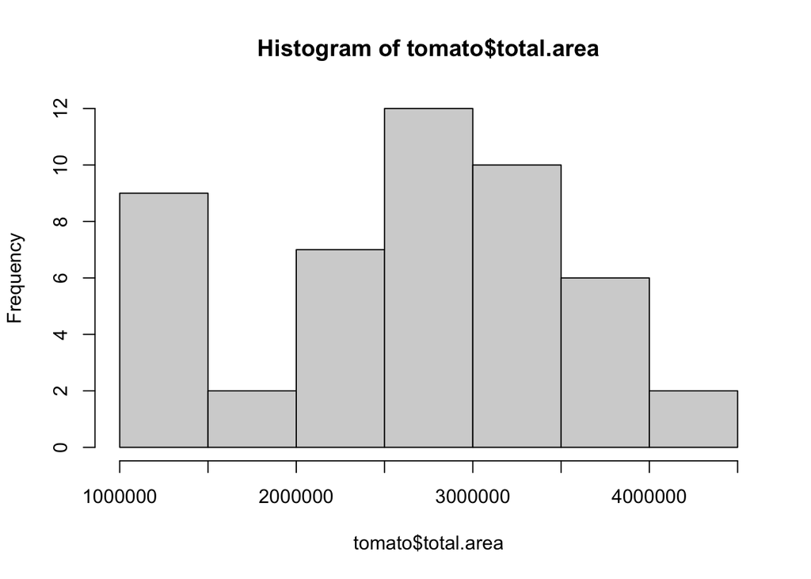

```r
hist(tomato$total.area)
```

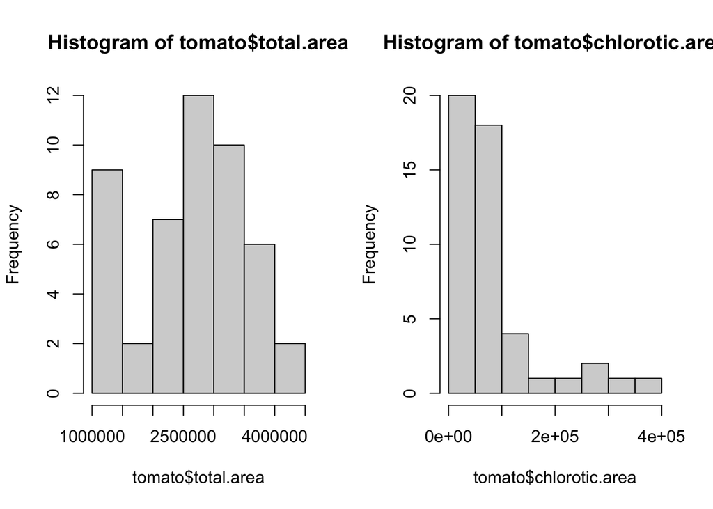

```r
par(mfrow=c(1,2))# Create a 1 x 2 plotting matrix
hist(tomato$total.area)
hist(tomato$chlorotic.area)
```

### 2.3.2 Boxplots

Scatterplot and boxplots are also very common to look at the distribution of your variables. Here are a few examples:

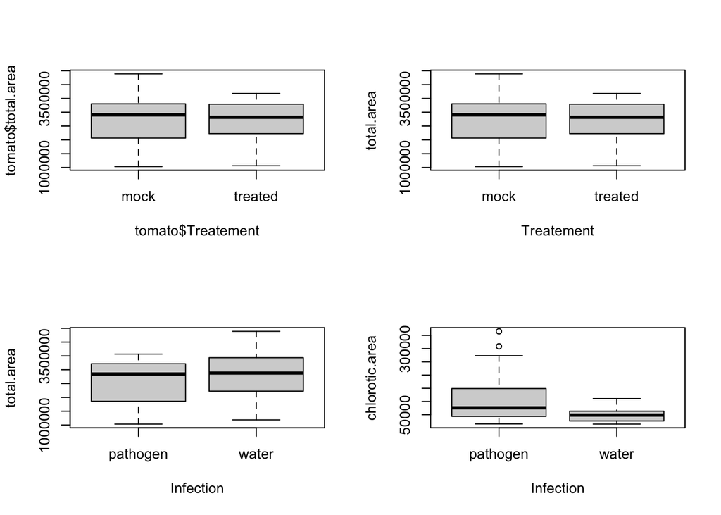

```r
par(mfrow=c(2,2))# Create a 2 x 2 plotting matrix
# The next 4 plots created will be plotted next to each other
plot(tomato$total.area~tomato$Treatement)
plot(total.area~Treatement, data=tomato) #this is the same but the XY labels change
plot(total.area~Infection, data=tomato)
plot(chlorotic.area~Infection, data=tomato)
```

What happens with an interaction?

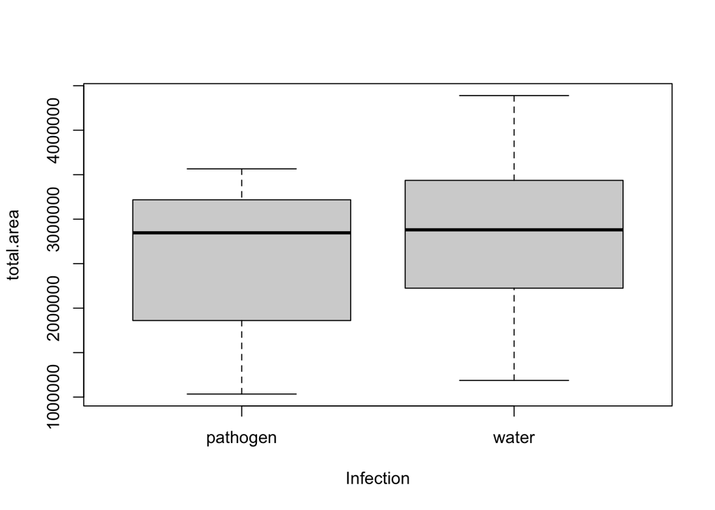

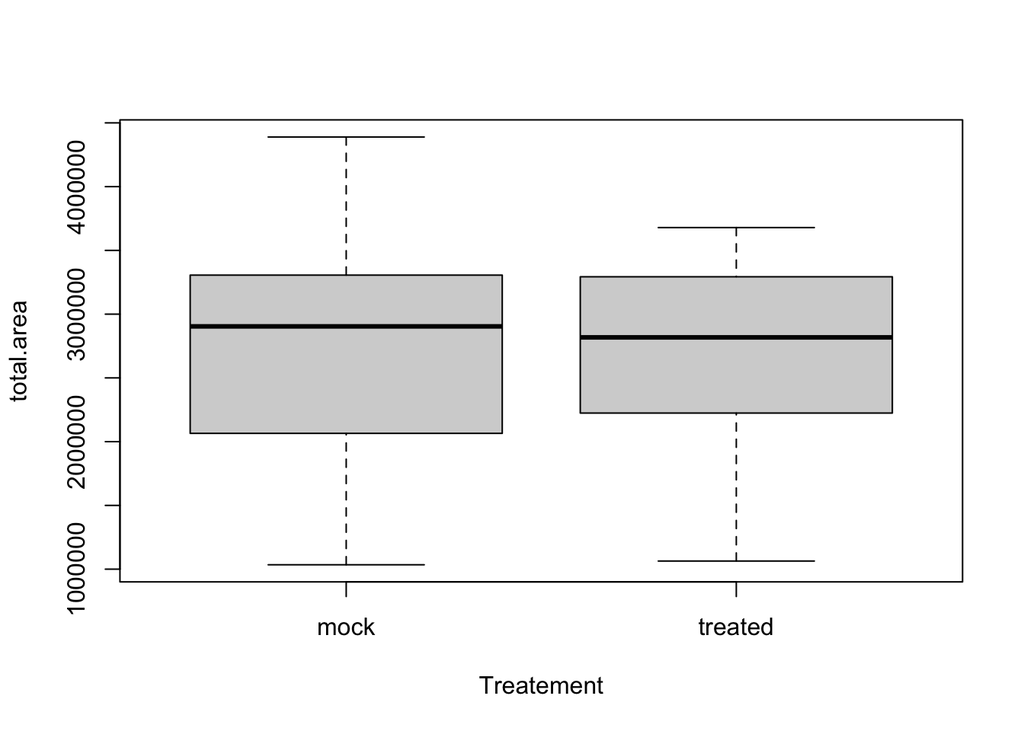

```r
plot(total.area~Infection*Treatement, data=tomato)
```

### 2.3.3 Scatterplots

They allow you to visualise all the data points

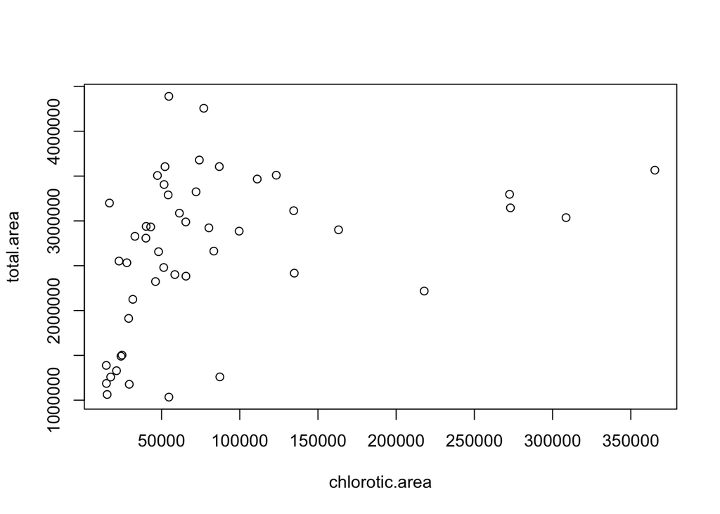

```r
plot(total.area~chlorotic.area, data=tomato)
```

### 2.3.4 Transform data directly in plots

You can apply transformation in your plot formula:

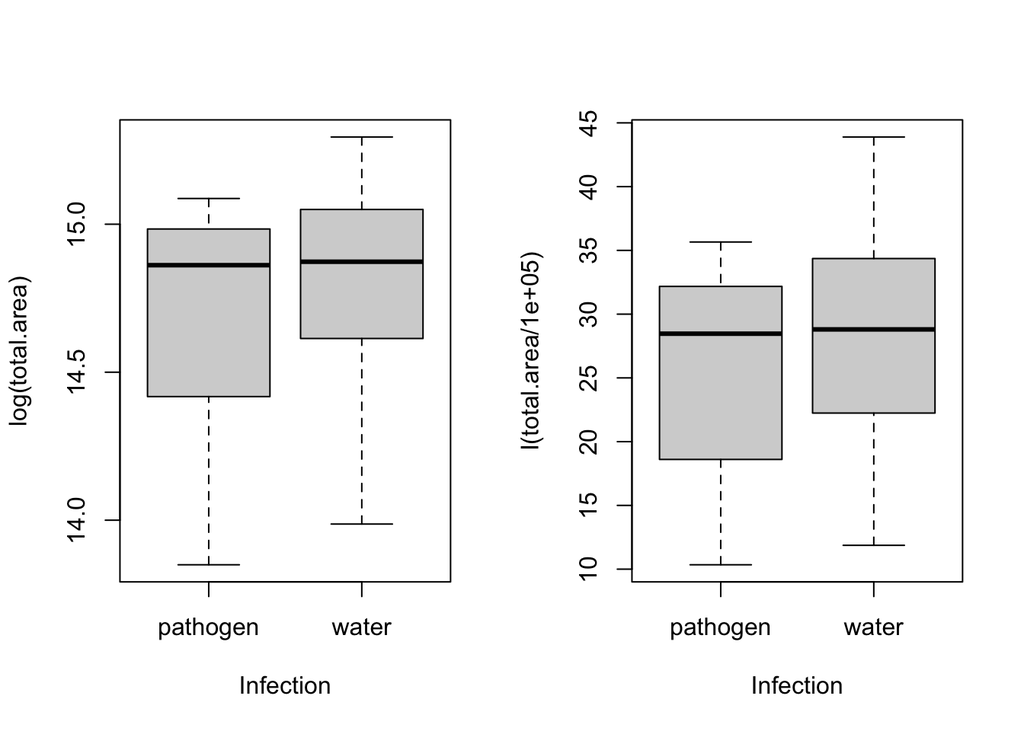

```r
par(mfrow=c(1,2))
plot(log(total.area)~Infection,data=tomato)
plot(I(total.area/100000)~Infection,data=tomato)
```

We can create new variables that combine Treatement and Infection as well as the ratio between both areas, then use it for plotting:

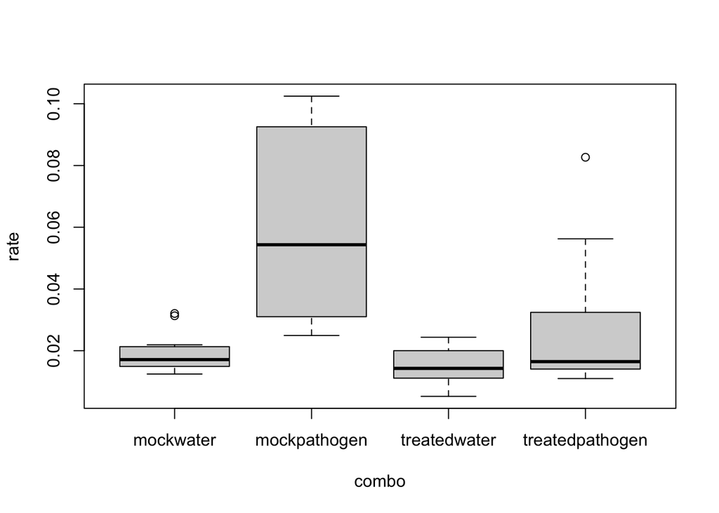

```r
tomato$combo<-as.factor(paste(tomato$Treatement,tomato$Infection,sep=""))
tomato$rate<-tomato$chlorotic.area/tomato$total.area
tomato$combo<-factor(tomato$combo,levels=levels(tomato$combo)[c(2,1,4,3)]) #here we reorder the levels
plot(rate~combo,data=tomato)
```

## 2.4 Challenge N˚3

**BONUS** Create a dataset for each rep and plot the ratio between chlorotic.area/total.area for the for combined levels (combo).

## 2.5 Loops

Loops are very useful, as they help us do similar operations multiple times while writing them only once. Let’s say you want to compute the mean chlorotic area for treated and untreated plants.

```r
mean_Mock <- mean(tomato$chlorotic.area[tomato$Treatement == "mock"])

mean_Treat <- mean(tomato$chlorotic.area[tomato$Treatement == "treated"])

cat("Mean chlorotic area (mock):", mean_Mock, "square mm" )
```

```
## Mean chlorotic area (mock): 104751.8 square mm
```

```r
cat("Mean chlorotic area (treated):", mean_Treat , "square mm")
```

```
## Mean chlorotic area (treated): 58670.88 square mm
```

```r
for (i in c('mock', 'treated')) {
  mean_value <- mean(tomato$chlorotic.area[tomato$Treatement == i])
  cat("Mean chlorotic area (",i,"):", mean_Mock, "square mm\n")
} # the \n character forces a line break
```

[output not shown]

It may not seems like much of a gain, but imagine if you had multiple levels to compute? Without a loop, you need 2 extra lines of code for every level. In a loop, you only need to add conditions to your vector.

## 2.6 Challenge N˚4

1. Compute the % chlorosis by total area for each sample as a new column;
2. Using a loop, compute the mean % chlorosis for every unique combination of `Treatment`, `Infection` and `rep` and print it to the console using `cat()` ;
3. Rerun your loop, but this time instead of printing to the console, save the values in a matrix. Hint: you can create an empty matrix with the appropriate dimensions and fill it using the loop and row/columns indices.

# 3 Session 3 - Tuesday AM

**Objectives:**

1. Learn the tidyverse syntax as an intuitive way to prepare our datasets.
2. learn to use the ggplot package!

```
install.packages('tidyverse') # super-package that includes ggplot
```

## 3.1 The tidyverse syntax

When working with large datasets with multiple variables, R can become cumbersome. Imagine having to change 20 character variables to factors, or modifying a recurring typo in a data frame with 2,000 rows… fortunately, it happened to enough people for the community to create new functions to help you write concise, powerful scripts.

Yesterday, we covered functions that are included “by default” in R, what we call the Base R language. Over time, a large library of functions was developed, called `tidyverse.` These functions let you modify your data in a very intuitive manner.

Let’s learn the tidyverse syntax!

### 3.1.1 Understanding pipes %>%

We introduce a modern syntax from the `tidyverse` superpackage, which uses the pipe operator `%>%`. You can print it by using the `shift+cmd+m` keyboard combination (or `shift+ctrl+m` on Windows).

To show its usefulness in making codes much easier to read, consider the following challenge: **Compute the mean proportion of chlorotic area of infected plants that were NOT treated, and format it to print as a percentage with 2 decimals.**.

A traditional base R code could look like this:

```r
which_observations <- which(tomato$Infection == 'pathogen' & tomato$Treatement == 'mock')
inf_treat_chlor_area <- tomato$chlorotic.area[which_observations]
inf_treat_total_area <- tomato$total.area[which_observations]
prop_area <- 100*inf_treat_chlor_area/inf_treat_total_area

paste('Mean proportion:', round(mean(prop_area),2), "%")
```

```
## [1] "Mean proportion: 5.97 %"
```

Now compare the same thing with the tidyverse syntax. We will use 3 new functions, namely:

-`mutate()` is used to create new variables from existing ones

-`filter()` subsets our rows based on the values of variables

-`pull()` which returns a dataset column as a vector

We’ll also introduce the pipe `%>%` operator, which is also available in base R as `|>` (choose your favourite!).

```r
library(tidyverse)

tomato_subset <- tomato %>%
  filter(Infection == 'pathogen' & Treatement == 'mock') %>%
  mutate(prop_area = 100*chlorotic.area/total.area)

# Compute the mean
tomato_subset %>%
  pull(prop_area) %>%
  mean() %>%
  round(2) %>%
  paste("Mean proportion:", ., "%")
```

```
## [1] "Mean proportion: 5.97 %"
```

Let’s switch to a new dataset with thousands of observations. We’ll look at it briefly, then select a few columns of interest using `select()` and modify variable classes using `mutate()`

```r
kangoroos <- read_xlsx('data/Marco_kangoroos.xlsx')
glimpse(kangoroos)
```

```
## Rows: 3,774
## Columns: 24
## $ ID              <dbl> 1, 1, 2, 3, 3, 3, 3, 3, 3, 3, 4, 5, 6, 6, 6, 6, 6, 6, …
## $ Sex             <chr> "M", "M", "F", "F", "F", "F", "F", "F", "F", "F", "F",…
## $ Age             <chr> "6", "8", "16", "0", "4", "5", "6", "7", "9", "10", "A…
## $ `Age certainty` <dbl> 4, 4, 4, 1, 1, 1, 1, 1, 1, 1, 0, 1, 4, 4, 4, 4, 4, 4, …
## $ Date            <chr> "Jul 27 08", "Nov 30 10", "Jul 27 08", "Jul 27 08", "S…
## $ No.             <dbl> 1, 2, 1, 1, 2, 3, 4, 5, 6, 7, 1, 1, 1, 2, 3, 4, 5, 6, …
## $ East            <chr> "7945", "8011", "8273", "8273", "8301", "8405", "8388"…
## $ North           <chr> "8411", "8325", "8362", "8362", "8163", "8337", "8431"…
## $ Method          <chr> "Crossbow", "Pole", "Crossbow", "PY", "T-pole", "T-pol…
## $ Year            <dbl> 2008, 2010, 2008, 2008, 2012, 2013, 2014, 2015, 2017, …
## $ Day             <dbl> 209, 334, 209, 209, 253, 246, 253, 295, 340, 255, 225,…
## $ Time            <dttm> NA, NA, NA, NA, NA, NA, 1904-01-01 07:45:00, 1904-01-…
## $ Mass            <dbl> 41.00, 46.25, 28.50, NA, 23.25, 26.00, 28.25, 28.50, 2…
## $ Foot            <dbl> 355.0, 367.0, 314.0, 174.0, 316.0, 317.0, 322.0, 323.0…
## $ Leg             <dbl> 595.0, 613.0, 515.0, 212.0, 502.0, 509.0, 517.0, 528.0…
## $ Arm             <dbl> 295, 316, NA, NA, 198, 212, 214, 222, 229, 225, 220, N…
## $ Teeth           <dbl> 3.0, 0.5, 3.0, NA, 2.0, 2.0, 1.5, 2.0, 1.5, 1.0, 1.0, …
## $ `Head length`   <dbl> NA, NA, NA, 99.4, NA, NA, NA, NA, NA, NA, NA, NA, NA, …
## $ Zygo            <chr> NA, NA, NA, NA, "89.7", "88.1", "92.5", "95.2", "95", …
## $ Notes           <chr> NA, NA, "mother of #3", "mother is #2", NA, "Mother of…
## $ Measurer        <dbl> 2, 1, 2, 2, 1, 1, 1, 8, 9, 1, 2, 2, 2, 1, 1, 3, 1, 1, …
## $ `new date`      <dttm> 2008-07-27, 2010-11-30, 2008-07-27, 2008-07-27, 2012-…
## $ `new birthdate` <dttm> NA, NA, NA, 2007-12-20, 2007-12-20, 2007-12-20, 2007-…
## $ `age months`    <dbl> NA, NA, NA, 7.236842, 56.743421, 68.552632, 80.789474,…
```

```r
kangoroos <- kangoroos %>%
  select(ID, Sex, Age, Mass, Leg, Date) %>%
  mutate(ID = as.factor(ID),
         Sex = as.factor(Sex),
         Age = as.numeric(Age))
```

```
## Warning: There was 1 warning in `mutate()`.
## ℹ In argument: `Age = as.numeric(Age)`.
## Caused by warning:
## ! NAs introduced by coercion
```

These warnings are suspicious! We’ll investigate them.

We can take advantage of that syntax to create more informative summaries of our data by using `group_by()`, a way to operate on subsets of our data without actually subsetting it; and passing the grouped dataframe to `summarise()`, which allows mathematical functions to be applied to every group.

```r
glimpse(kangoroos)
```

```
## Rows: 3,774
## Columns: 6
## $ ID   <fct> 1, 1, 2, 3, 3, 3, 3, 3, 3, 3, 4, 5, 6, 6, 6, 6, 6, 6, 6, 6, 7, 7,…
## $ Sex  <fct> M, M, F, F, F, F, F, F, F, F, F, F, F, F, F, F, F, F, F, F, F, F,…
## $ Age  <dbl> 6, 8, 16, 0, 4, 5, 6, 7, 9, 10, NA, 0, 12, 13, 14, 15, 16, 17, 18…
## $ Mass <dbl> 41.00, 46.25, 28.50, NA, 23.25, 26.00, 28.25, 28.50, 29.50, 27.75…
## $ Leg  <dbl> 595.0, 613.0, 515.0, 212.0, 502.0, 509.0, 517.0, 528.0, 533.0, 52…
## $ Date <chr> "Jul 27 08", "Nov 30 10", "Jul 27 08", "Jul 27 08", "Sept 9 12", …
```

```r
kang_group_summary <- kangoroos %>%
  drop_na(Age, Sex) %>%
  group_by(Sex) %>%
  summarise(mean_age = mean(Age),
            sd_age = sd(Age),
            n_obs = n()
            )

kang_group_summary
```

```
## # A tibble: 2 × 4
##   Sex   mean_age sd_age n_obs
##   <fct>    <dbl>  <dbl> <int>
## 1 F         4.99   4.55  1900
## 2 M         2.87   3.91  1107
```

Doing this using base R syntax would have required many intermediate objects, whereas here we get the end product with a single pipe that does all we need.

```r
library(kableExtra)
kang_group_summary %>%
  mutate(across(where(is.numeric), ~ round(., 1))) %>%
  kable(col.names = c("Sex", "Mean Age", "SD Age", "N")) %>%
  kable_styling("striped")
```

| Sex | Mean Age | SD Age | N |
| --- | --- | --- | --- |
| F | 5.0 | 4.5 | 1900 |
| M | 2.9 | 3.9 | 1107 |

Here’s a fun operator, the assignment pipe `%<>%`. It acts as both a pipe and an assignment. It allows you to modify an object without creating a new object. You need to explicitly load the `magrittr` library even if tidyverse is loaded already.

```r
library(magrittr)
kangoroos %<>%
  mutate(Date = case_when(
    str_detect(Date, 'Sept') ~ str_replace(Date, 'Sept', 'Sep'),
               TRUE ~ Date),
    Date = parse_date_time(Date, orders = c('%m%d%y')),
    across(where(is.character), as.factor)
 )

kangoroos
```

```
## # A tibble: 3,774 × 6
##    ID    Sex     Age  Mass   Leg Date
##    <fct> <fct> <dbl> <dbl> <dbl> <dttm>
##  1 1     M         6  41     595 2008-07-27 00:00:00
##  2 1     M         8  46.2   613 2010-11-30 00:00:00
##  3 2     F        16  28.5   515 2008-07-27 00:00:00
##  4 3     F         0  NA     212 2008-07-27 00:00:00
##  5 3     F         4  23.2   502 2012-09-09 00:00:00
##  6 3     F         5  26     509 2013-09-03 00:00:00
##  7 3     F         6  28.2   517 2014-09-10 00:00:00
##  8 3     F         7  28.5   528 2015-10-22 00:00:00
##  9 3     F         9  29.5   533 2017-12-06 00:00:00
## 10 3     F        10  27.8   524 2018-09-12 00:00:00
## # ℹ 3,764 more rows
```

## 3.2 Challenge N˚4

Using the `summarise()` command, find the mean Leg length and body mass for each sex at every age.

## 3.3 Plotting using ggplot

In this intro to GGplot2 we will look at mapping, layers, and scales. In `ggplot()`, you map your variables to what are called aesthetics and you add on layers to generate a plot that uses those mappings. You can then add in scales to further manipulate your plot.

We will map or select the data using `aes()`. Then we will select the type of graph we want using using a geom, for example: `geom_histogram()`; `geom_point()`; `geom_boxplot()`, geom_col(), `geom_line()`. We will make 4 plots, for each one we will learn a new syntax,slowly adding layers to the plot.

### 3.3.1 Histograms

The simplest plot which only uses a x **or** y aesthetic, to count frequencies.

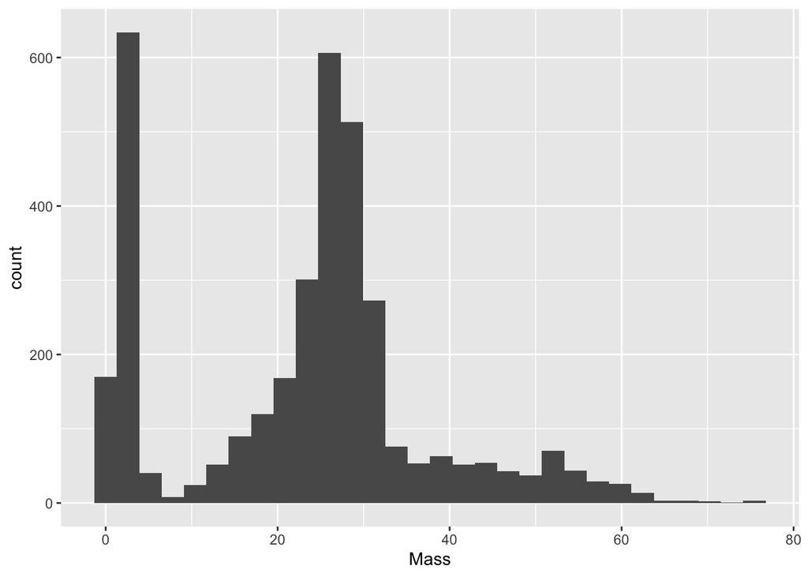

```r
kangoroos %>%
  drop_na(Mass) %>%
  ggplot(aes(x = Mass)) +
  geom_histogram()
```

### 3.3.2 Scatterplots

We’ll map another variable and add colours, using the `color = ...` argument in `geom_point()`

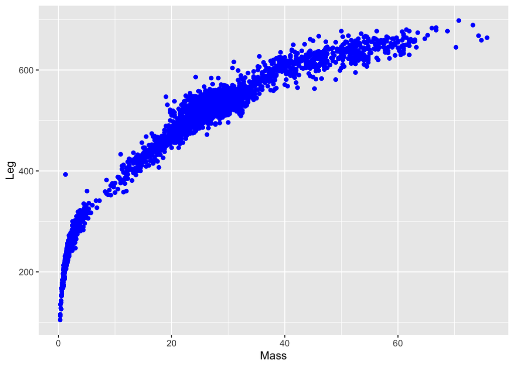

```r
kangoroos %>%
  drop_na(Mass, Leg) %>%
  ggplot(aes(x = Mass, y = Leg)) +
  geom_point(color = "blue")
```

### 3.3.3 Boxplots

selecting color using `color = ...` and `fill = ...` in `geom_boxplot()` #Add labels and titles using labs(title=“name”, x =“name”, y=“name”)

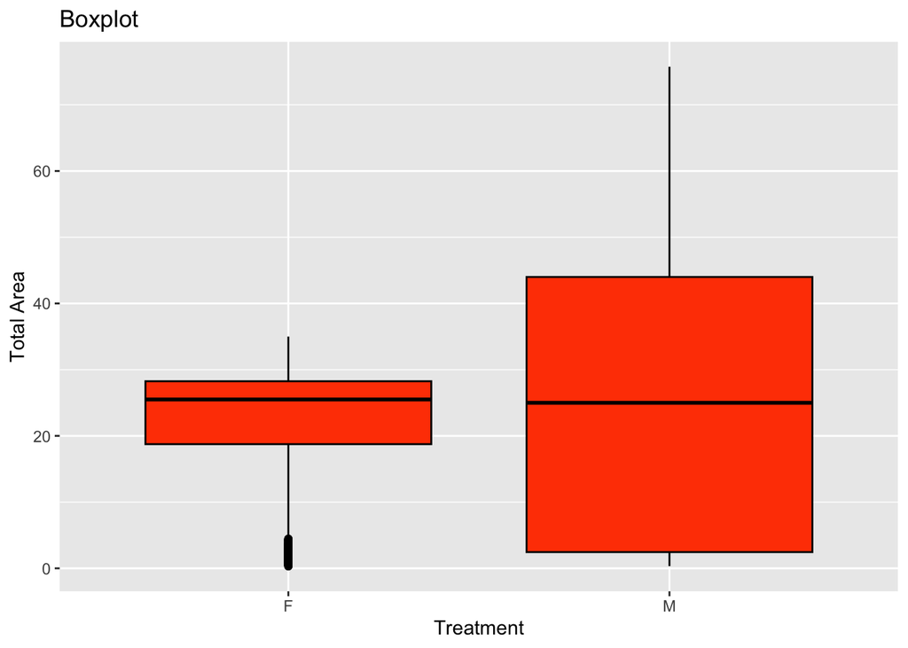

```r
kangoroos %>%
  drop_na(Sex, Mass) %>%
  ggplot(aes(x = Sex, y = Mass)) +
  geom_boxplot(color="black", fill = "orangered") +
  labs(title = "Boxplot", x = "Treatment", y = "Total Area")
```

### 3.3.4 Bar (column) plot

Selecting color using `aes(fill = ...)` and adding labels and titles.

[output not shown]

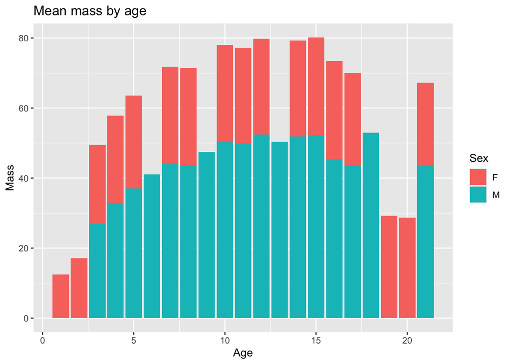

```r
kangoroos %>%
  group_by(Age, Sex) %>%
  summarise(mean_mass = mean(Mass)) %>%
  drop_na() %>%
  ggplot(aes(x = Age,
             y = mean_mass,
             fill = Sex)
  ) +
  geom_col() +
  labs(title = "Mean mass by age", x = "Age", y = "Mass")
```

By default geom_col will stack each observation on top of each other for each x axis value. You can place them next to each other using `geom_col(position = "dodge")`

[output not shown]

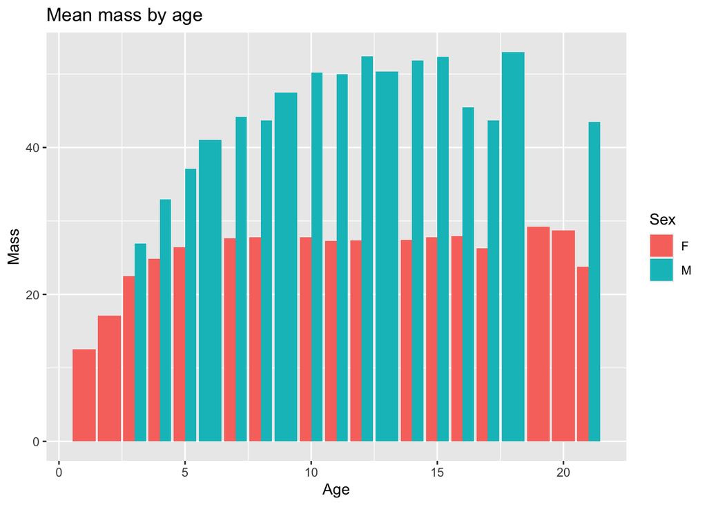

```r
kangoroos %>%
  group_by(Age, Sex) %>%
  summarise(mean_mass = mean(Mass)) %>%
  drop_na() %>%
  ggplot(aes(x = Age,
             y = mean_mass,
             fill = Sex)
  ) +
  geom_col(position = 'dodge') +
  labs(title = "Mean mass by age", x = "Age", y = "Mass")
```

### 3.3.5 Faceting plots

[figure not shown]

```r
kangoroos %>%
  drop_na() %>%
  ggplot(aes(x = Leg,
             y = Mass,
             colour = Age)) +
  geom_point() +
  facet_wrap(~Sex) +
  labs(title = "Mass and length of leg along age", x = "Mass", y = "Leg length")
```

### 3.3.6 Adding points using jitter

We can add all data points on top of a box plot using `geom_jitter()` Notice what happens when you place jitter before vs. after geom_boxplot. We’ll also change the theme here, because that’s an option!

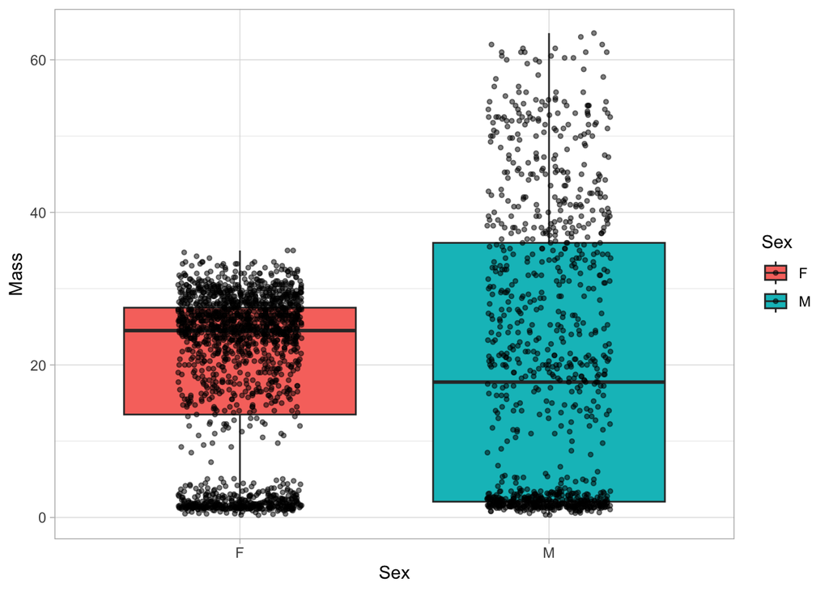

```r
kangoroos %>%
  drop_na() %>%
  ggplot(aes(x = Sex,
             y = Mass,
             fill = Sex)) +
  geom_boxplot() +
  geom_jitter(width = 0.2, alpha = 0.5, size = 1) +
  labs(x = "Sex", y = "Mass") +
  theme_light()
```

### 3.3.7 Line plots

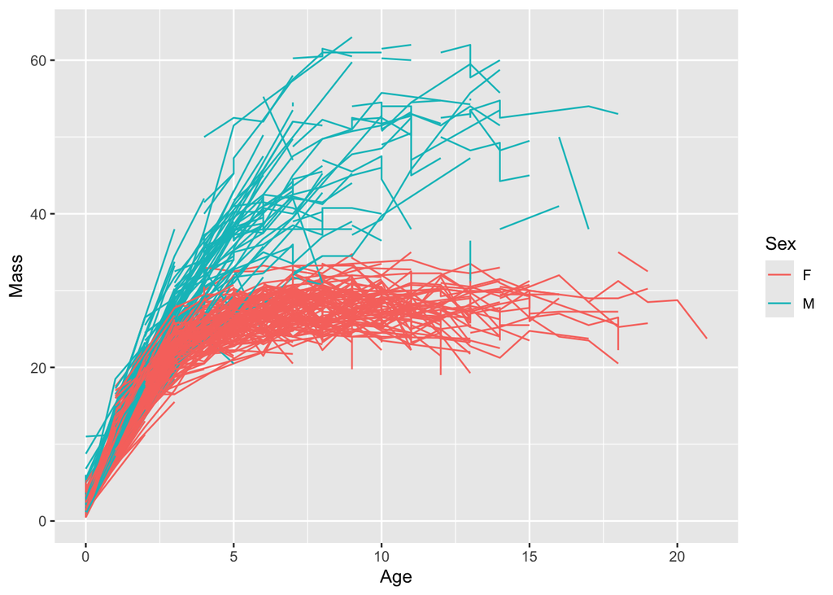

```r
kangoroos %>%
  drop_na() %>%
  ggplot(aes(x = Age,
             y = Mass,
             group = ID,
             color = Sex)
  ) +
  geom_line() +
  labs(x = "Age", y = "Mass")
```

```r
# kangoroos %>%
#   ggplot(aes(x = rownames(tomato_mdf),
#              y = total.area, group = Treatment,
#              color = Treatment)
#   ) +
#   geom_line() +
#   scale_x_discrete(limits = sort(as.numeric(rownames(tomato_mdf)))) +
#   labs(title = "Lineplot with Reordered Row Names", x = "Row Names", y = "Total Area")
```

## 3.4 Challenge N˚6

1. Make a violin plot of the proportion of chlorosis for each treatment state using `geom_violin()`
2. Add the points on top of the violins
3. Add labels
4. Map the shape of the points to the `rep` variable (hint: you can reuse the `aes()` function inside any geom, here’s a [reference](https://www.sthda.com/english/wiki/ggplot2-point-shapes))
5. Facet this plot by infection state
6. Use the minimal theme
7. Change the colours of the violins to “darkred” and “midnightblue” (hint: check the `scale_fill_manual()` function)
8. Save your plot using the `ggsave()` function as a 1400 x 1200 pixels file in .png format

# 4 Session 4 - Tuesday PM

# 5 Session 5 - Wednesday AM

# 6 Session 6 - Wednesday PM